# A3: SPL Library Checkouts

### Introduction

The following is taken from an ambitious collection of data: the complete checkout history of the Seattle Public Library this year. Just looking at the raw csv file makes you realize how much work there is that goes into tracking and maintaining a library system. And so… many… books. Seeing this wall of information made me curious of the technical aspect of maintaining a library. It’s the 21st century, what sort of things are people checking out, and HOW are they checking them out. Suffice to say, that’s the crux of this report I’ve made for A3. I want to see the “physical” side of the library system. What is the digital medium of these transactions, and how have they fluctated throughout the year?

### The Dataset

This dataset comes from the Seattle Public Library, so straight from the source. Accuracy of the data, in this case, is a given. The data includes every aspect to know of each book: the number of checkouts, time of checkouts, genre, publisher, etc. It’s an extremely sprawling parameter, but seeing that it’s from directly the computer system of the SPL, that seems obvious. The data was collected because, well, someone has to keep track of things. Especially in a government sector like this, everything needs to have oversight, and to do that every minue detail must be accounted for. There are no ethical dilemmas with this data, unless you feel like it’s wrong for a library to know what books you’ve been checking out. The only limitatioin I can see for this dataset is just its sheer size. My laptop takes forever to render some of the these graphs, and it sometimes crashes when I go to open up the csv to check some things. It’s a bit “too” detailed, but honestly it’s a luxury to be even able to complain about that sort of thing.

### First Trends Over Time Chart

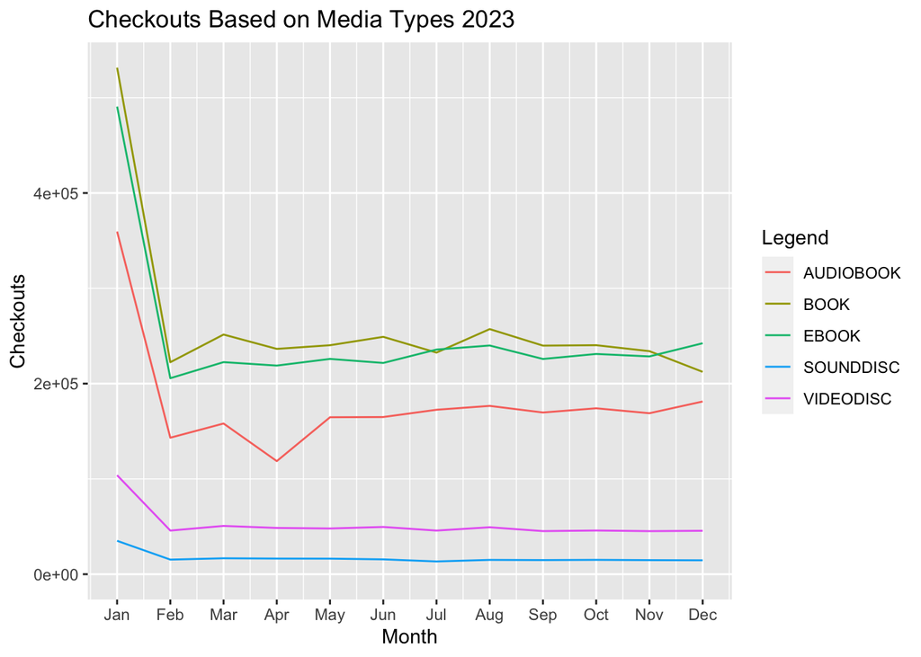